# H03 Stage 2: implementation, diagnostics, and V0 comparison

- Show All Code
- Hide All Code
- View Source

Nature Health analysis audit — author result gate

Published

August 7, 2026

**ImportantResult at the Stage 2 gate**

The signed hypothesis is:

> **H3: Hourly self-reported light exposure categories predict hourly geometric mean melanopic EDI.**

The seven self-reported primary-light-source categories are associated with measured one-hour near-eye melEDI in the prespecified primary omnibus, *F*(6, 139) = 97.54, *p* <0.001. Relative to indoor electric light and after the six-contrast BH correction, near-eye melEDI was higher for indoor daylight and outdoor daylight and lower for emissive display, sleep darkness, and external light during sleep. Outdoor electric light was not distinguishable from indoor electric light.

The full seven-category site-heterogeneity architecture passed its predeclared, effect-blind estimability gate. Site heterogeneity was strong, *F*(48, 139) = 79.99, *p* <0.001, so the site-standardized ratios are cross-site summaries, not uniform effects that apply identically at every site.

The primary model is numerically stable and full rank, but it is not a well-calibrated Tweedie probability model: residual variance remains strongly fitted-value dependent, repeated hours remain correlated, and the working Tweedie zero mass substantially exceeds the observed zero fraction. Its defensible role is therefore a participant-cluster-robust population-mean analysis. It does not support causal, health-outcome, or placement-equivalence claims.

## 1 What was fitted

Near-eye is primary. Chest is complementary. The exact one-hour response is the accepted zero-aware geometric melEDI outcome; no H02 fitted value, prediction, significance result, or claim was reused.

The primary model has fixed site and light-source terms, a log link, and the working quasi-Tweedie variance power 1.539919. Site uses submitted-order sum coding. Light source uses indoor electric light as the treatment reference. Participant-clustered HC1 covariance, with finite cluster *t* and *F* reference distributions, carries the repeated-hour and repeated-day uncertainty. This is a population-mean model, so an lme-style random-effect singularity parameter does not exist; full design rank and covariance positive-definiteness are the relevant numerical checks.

The category means and ratios use the submitted site set with each site receiving the same weight on the fitted log-mean scale, followed by one inverse link transformation. “Site-standardized” is used below for this geometric mean of the fitted site-specific expected values.

### 1.1 Exact evaluated formulas

**Show audit code**

```r
formulas |>
  filter(.data$formula_id %in% c(
    "primary_population_mean",
    "full_site_heterogeneity",
    "chest_observed_cell_heterogeneity",
    "secondary_mundlak_audit",
    "v0_bridge_full",
    "v0_bridge_site_only",
    "temporal_category"
  )) |>
  transmute(
    Model = .data$formula_id,
    `Exact Wilkinson formula supplied to R` = .data$formula
  ) |>
  audit_gt(
    "Evaluated H03 formulas",
    "Displayed from the run registry; this report reads saved artifacts and fits no model"
  ) |>
  cols_width(Model ~ pct(25), `Exact Wilkinson formula supplied to R` ~ pct(75))
```

Table 1

Evaluated H03 formulas

Displayed from the run registry; this report reads saved artifacts and fits no model

| Model | Exact Wilkinson formula supplied to R |
| --- | --- |
| primary_population_mean | geo_medi_1h ~ site + light_source |
| full_site_heterogeneity | geo_medi_1h ~ site * light_source |
| chest_observed_cell_heterogeneity | geo_medi_1h ~ 0 + site_source_cell |
| secondary_mundlak_audit | geo_medi_1h ~ site + light_source + between_source_1 + between_source_2 + between_source_3 + between_source_4 + between_source_5 + between_source_6 |
| v0_bridge_full | geo_medi_1h ~ site * light_source_v0 + (1 \| participant) |
| v0_bridge_site_only | geo_medi_1h ~ site + (1 \| participant) |
| temporal_category | h03_temporal_response ~ s(time_hour, bs = "cc", k = 12) + s(time_hour, light_source, bs = "sz", k = 12) + s(time_hour, site, bs = "sz", k = 12) + s(time_hour, participant, bs = "fs", k = 10) + s(parti… |

### 1.2 Exact analytical samples

Table 2: Exact primary and complementary fitted samples.

Fitted sample

One observation is one accepted participant-hour

| Placement | Participant-hours | Participants | Participant-days | Sites | Exact-zero hours | Boundary hours |
| --- | --- | --- | --- | --- | --- | --- |
| Near-eye | 17,935 | 140 | 801 | 9 | 4,977 | 2,396 |
| Chest | 19,512 | 151 | 880 | 8 | 5,409 | 2,570 |

The near-eye model contains 17,935 participant-hours from 140 participants, 801 participant-days, and nine sites. The chest model contains 19,512 participant-hours from 151 participants, 880 participant-days, and eight sites. These are row, participant, day, and site denominators respectively; they are not interchangeable.

## 2 Category association and practical contrasts

Table 3: Site-standardized category estimates and contrasts to indoor electric light.

Primary near-eye and complementary chest estimates

Participant-cluster-robust 95% confidence intervals. Six non-reference contrasts per placement; BH-adjusted p is bold only when significant at 0.050. Raw p has no bolding rule.

| Category | Expected melEDI, lx (95% CI) | Ratio to indoor electric (95% CI) | Raw p | BH-adjusted p |
| --- | --- | --- | --- | --- |
| Near-eye |  |  |  |  |
| Indoor electric | 88.9 (75.0 to 105.3) | Reference | — | — |
| Outdoor electric | 81.6 (28.9 to 230.7) | 0.918 (0.321 to 2.621) | 0.872 | 0.872 |
| Indoor daylight | 205.1 (172.7 to 243.5) | 2.307 (1.846 to 2.885) | <0.001 | **<0.001** |
| Outdoor daylight | 1033.5 (837.3 to 1275.8) | 11.629 (8.939 to 15.130) | <0.001 | **<0.001** |
| Emissive display | 53.1 (35.8 to 79.0) | 0.598 (0.397 to 0.901) | 0.014 | **0.017** |
| Sleep darkness | 2.7 (1.5 to 5.0) | 0.031 (0.017 to 0.057) | <0.001 | **<0.001** |
| External light during sleep | 39.9 (21.4 to 74.5) | 0.449 (0.246 to 0.821) | 0.010 | **0.015** |
| Chest |  |  |  |  |
| Indoor electric | 88.3 (74.9 to 104.2) | Reference | — | — |
| Outdoor electric | 54.9 (29.3 to 102.9) | 0.622 (0.350 to 1.103) | 0.103 | 0.103 |
| Indoor daylight | 229.9 (196.8 to 268.5) | 2.603 (2.130 to 3.181) | <0.001 | **<0.001** |
| Outdoor daylight | 1310.1 (1044.1 to 1643.8) | 14.833 (11.390 to 19.317) | <0.001 | **<0.001** |
| Emissive display | 51.1 (35.6 to 73.4) | 0.579 (0.400 to 0.838) | 0.004 | **0.006** |
| Sleep darkness | 3.8 (1.5 to 9.7) | 0.044 (0.017 to 0.110) | <0.001 | **<0.001** |
| External light during sleep | 32.6 (13.5 to 78.7) | 0.370 (0.164 to 0.835) | 0.017 | **0.020** |

For near-eye melEDI, the site-standardized indoor-electric anchor is 88.9 lx. The estimated ratios are 2.31 for indoor daylight, 11.63 for outdoor daylight, 0.60 for emissive display, 0.031 for sleep darkness, and 0.45 for external light during sleep. These are observational category associations relative to indoor electric light.

**NoteWhy the preliminary 88.9 lx value is retained**

The volatile explainer used the same 17,935-hour frame and the same additive quasi-Tweedie mean model. Its 88.9 lx indoor-electric value was obtained by averaging the nine site linear predictors and then back-transforming:

$$\exp\left(S^{-1}\sum_s \eta_{sc}\right).$$

That is the geometric mean of the site-specific expected values. Following the author’s 2026-08-07 amendment, this is also the approved Stage 2 estimand. The intermediate Stage 2 render instead averaged the expected values in melEDI units:

$$S^{-1}\sum_s \exp(\eta_{sc}).$$

For indoor electric light, the nine fitted site means range from 42.8 to 152.6 lx. Their geometric mean is 88.9 lx, reproducing the preliminary 88.9 lx after rounding; their equal-site arithmetic mean is 97.1 lx. The arithmetic mean is 8.2 lx, or 9.3%, higher. The now-superseded 97.1 lx value therefore reflected only a different standardization/back-transformation order, not a sample or fitted-model change. Because site and category are additive on the log scale, this common site factor cancels from category ratios; the fitted category coefficients, ratios, and omnibus test are unchanged. Absolute-mean confidence intervals use the delta-method gradient for the approved link-scale standardization.

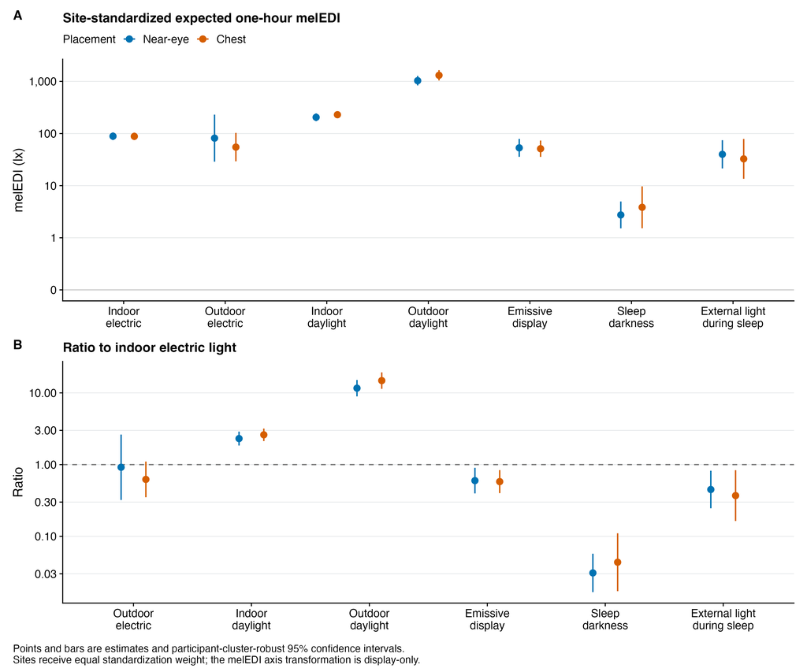

Figure 1: Site-standardized one-hour melEDI estimates and ratios to indoor electric light. The melEDI transformation is display-only.

### 2.1 Omnibus and heterogeneity tests

Table 4

Prespecified omnibus tests

Near-eye F1/F3 are primary; chest tests are complementary mirrors. Each omnibus p is unadjusted and bold only at 0.050.

| Test | F (numerator df, denominator df) | p | Architecture |
| --- | --- | --- | --- |
| Near-eye |  |  |  |
| Category association | 97.54 (6, 139) | **<0.001** | NA |
| site_heterogeneity_omnibus | 79.99 (48, 139) | **<0.001** | full_literal |
| Chest |  |  |  |
| Category association | 82.21 (6, 150) | **<0.001** | NA |
| site_heterogeneity_omnibus | 13.15 (41, 150) | **<0.001** | full_observed_cell |

The interaction is not folded into the primary additive mean model because it answers a different question and requires many more supported coefficients. The category omnibus asks whether the site-standardized category pattern is flat. The interaction gate asks whether that category pattern varies by site. Separating them preserves the hierarchy and prevents unsupported site cells from determining whether the pooled category question can be asked.

## 3 Site heterogeneity and sparse cells

The effect-blind architecture gate passed before interaction estimates or interaction p-values were emitted. Near-eye used the literal seven-category `site * light_source` formula. Chest had one structural cell absence and used the algebraically equivalent observed-cell parameterization. The five-category fallback was not invoked.

Table 5

Interaction architecture gate

No interaction estimate, p-value, or claim was inspected to select the architecture

| Placement | Architecture | Observations | Design rank / columns | Restrictions | Restriction covariance condition | Largest cluster score share | Largest cluster leverage share | Passed |
| --- | --- | --- | --- | --- | --- | --- | --- | --- |
| Near-eye | full_literal | 17,935 | 63 / 63 | 48 | 3709.3 | 0.329 | 0.031 | TRUE |
| Chest | full_observed_cell | 19,512 | 55 / 55 | 41 | 90.4 | 0.062 | 0.027 | TRUE |

Table 6

Site-specific estimability and heterogeneity

F4 uses one BH family across supported near-eye site deviations; chest is the complementary mirror.

| Category | Site rows | Estimable | Support-non-estimable | Other non-estimable / not applicable | BH-significant site deviations |
| --- | --- | --- | --- | --- | --- |
| Near-eye |  |  |  |  |  |
| Indoor electric | 9 | 9 | 0 | 0 | 6 |
| Outdoor electric | 9 | 4 | 5 | 0 | 3 |
| Indoor daylight | 9 | 9 | 0 | 0 | 1 |
| Outdoor daylight | 9 | 9 | 0 | 0 | 2 |
| Emissive display | 9 | 8 | 1 | 0 | 5 |
| Sleep darkness | 9 | 9 | 0 | 0 | 2 |
| External light during sleep | 9 | 5 | 4 | 0 | 2 |
| Chest |  |  |  |  |  |
| Indoor electric | 9 | 8 | 0 | 1 | 3 |
| Outdoor electric | 9 | 4 | 4 | 1 | 2 |
| Indoor daylight | 9 | 8 | 0 | 1 | 3 |
| Outdoor daylight | 9 | 8 | 0 | 1 | 2 |
| Emissive display | 9 | 7 | 1 | 1 | 4 |
| Sleep darkness | 9 | 8 | 0 | 1 | 2 |
| External light during sleep | 9 | 0 | 2 | 7 | 0 |

Across both placements, 96 of 126 site-category rows provide supported site-specific deviations; 17 are support-non-estimable, one is a structural cell absence, five cannot form their site-standardized category comparison, and seven are not applicable. Thirty-seven supported site deviations pass their stated BH label. Unsupported rows remain visible as crosses rather than being silently dropped.

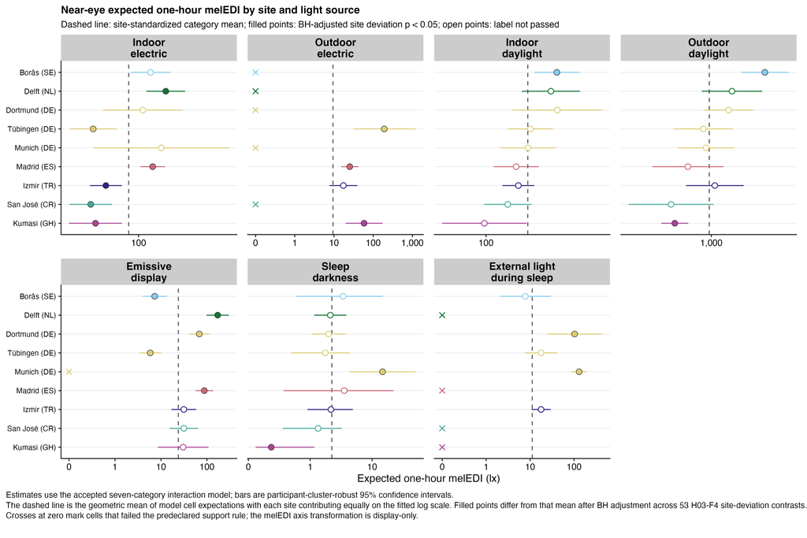

Figure 2: Near-eye site-specific expected one-hour melEDI from the accepted interaction model. In each light-source panel, the dashed vertical line is the site-standardized geometric mean with equal site contributions on the fitted log scale. Filled circles identify site deviations with BH-adjusted p < 0.05 in the 53-member H03-F4 family; open circles do not pass that label. Crosses at zero identify prespecified support failures and are not zero-valued estimates.

## 4 Diagnostics and influence

### 4.1 Numerical, distributional, zero-mass, and temporal checks

Table 7

Primary-model diagnostics

PD = positive definite. Dependence and heteroskedasticity are interpreted below, not treated as pass/fail decorations.

| Placement | Converged | Full rank | Robust covariance PD | Covariance condition | Exact-zero fraction | \|residual\|-fitted Spearman | Boundary-aware lag-1 residual r | Largest cluster score share | Largest cluster leverage share |
| --- | --- | --- | --- | --- | --- | --- | --- | --- | --- |
| Near-eye | TRUE | TRUE | TRUE | 162.0 | 0.278 | 0.554 | 0.478 | 0.334 | 0.016 |
| Chest | TRUE | TRUE | TRUE | 191.3 | 0.277 | 0.565 | 0.615 | 0.393 | 0.016 |

Both fits converged without warnings, have full design rank, and have finite positive-definite participant-cluster covariances. There is no mixed-model singularity question because these are GLMs. Exact zeros constitute about 27.7% of either outcome. Absolute residual magnitude remains strongly related to the fitted mean, and boundary-aware lag-1 residual correlation is 0.478 near eye and 0.615 at chest. Participant clustering permits arbitrary within-participant dependence in the sandwich covariance, but it does not make these residual patterns disappear or validate the working distribution.

Table 8

Working zero mass

The compound-Poisson expression is a diagnostic implied by the fitted mean, power, and dispersion. The quasi-likelihood model does not fit a zero-mass likelihood.

| Placement | Observations | Observed zero fraction | Working Tweedie zero fraction | Observed minus working | Zero Brier score |
| --- | --- | --- | --- | --- | --- |
| Chest | 19,512 | 0.277 | 0.948 | -0.671 | 0.633 |
| Near-eye | 17,935 | 0.278 | 0.852 | -0.575 | 0.489 |

The implied working Tweedie zero fractions are 0.852 near eye and 0.948 at chest, far above the observed 0.278 and 0.277. This is a clear distributional miscalibration. It rules out interpreting the fitted family as a realistic generative distribution. The estimates remain usable as a log-mean model with participant-cluster-robust covariance if the site-and-category mean structure is the target; efficiency and small-sample calibration may be imperfect.

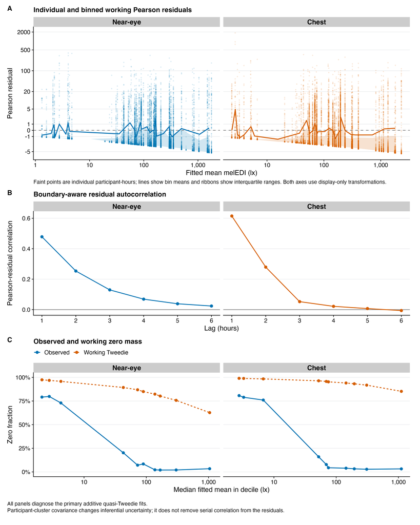

Figure 3: Primary additive quasi-Tweedie diagnostic plots. Panel A overlays every participant-hour Pearson residual with binned means and interquartile ranges; Panel B shows boundary-aware residual correlations across one- to six-hour lags; Panel C compares observed and working-Tweedie zero fractions across fitted-mean deciles. Plot transformations are display-only.

### 4.2 Descriptive fixed-effect R² and bounded Gaussian comparison

An ordinary mixed-model marginal/conditional R² is not defined for the primary analysis because the fitted model contains no random effects. Participant clustering changes the covariance used for inference, not the fitted values. The descriptive summary is now calculated for the accepted heterogeneity architecture: the literal `site * light_source` model near eye and its rank-complete observed-cell parameterization, `0 + site_source_cell`, at chest, where one cell is structurally absent. It uses the intercept-only, site-only, category-only, additive, and accepted full-heterogeneity fits:

- overall R² uses the full interaction model;
- the interaction partial R² compares the full model with its hierarchical additive reduction; and
- the hierarchy-respecting allocation averages the two entry orders for the site and category main effects, then adds the interaction only after both main effects. The three allocations sum exactly to overall R².

Table 9

Descriptive R² for the accepted fixed-effect heterogeneity model

Allocations are R² units with the percentage of total R² in parentheses. Point estimates only; no cluster-bootstrap intervals or additional effect tests were computed.

| Definition | Overall | Category partial \| site | Site partial \| category | Interaction partial \| additive | Category allocation | Site allocation | Interaction allocation |
| --- | --- | --- | --- | --- | --- | --- | --- |
| Near-eye |  |  |  |  |  |  |  |
| Working quasi-Tweedie deviance | 0.522 | 0.462 | 0.051 | 0.052 | 0.450 (86.3%) | 0.045 (8.7%) | 0.026 (5.0%) |
| Participant-hour squared error | 0.129 | 0.105 | 0.027 | 0.018 | 0.096 (74.9%) | 0.017 (12.9%) | 0.016 (12.2%) |
| Participant-balanced squared error | 0.128 | 0.103 | 0.026 | 0.019 | 0.095 (74.4%) | 0.016 (12.6%) | 0.017 (13.0%) |
| Chest |  |  |  |  |  |  |  |
| Working quasi-Tweedie deviance | 0.536 | 0.461 | 0.035 | 0.082 | 0.454 (84.7%) | 0.040 (7.6%) | 0.041 (7.7%) |
| Participant-hour squared error | 0.152 | 0.115 | 0.036 | 0.034 | 0.101 (66.7%) | 0.021 (13.6%) | 0.030 (19.6%) |
| Participant-balanced squared error | 0.149 | 0.112 | 0.036 | 0.035 | 0.098 (65.9%) | 0.020 (13.5%) | 0.031 (20.6%) |

For the near-eye primary model, working quasi-deviance R² is 0.522; the participant-hour and participant-balanced squared-error R² values are 0.129 and 0.128. The category block accounts for most of the fitted gain under each definition, while the interaction contribution is now shown explicitly. The allocations are descriptive associations and not causal variance contributions. Different R² definitions answer different scale-and-weighting questions and should not be merged into one headline value.

The Gaussian check remains a separate comparison of the additive category-association architecture across response families; it is not an interaction-selection analysis. It used the same exact fitted samples and was deterministic and bounded: five participant-blocked folds, stratified within site, with every participant assigned to exactly one test fold. It involved 30 fits and no resampling simulation.

**Show audit code**

```r
glm_candidate_registry |>
  transmute(
    Candidate = .data$model_label,
    `Exact Wilkinson formula` = .data$exact_formula,
    Family = .data$family_label,
    `Outcome target` = .data$outcome_target
  ) |>
  audit_gt(
    "Bounded GLM comparison candidates",
    "The transformed Gaussian changes the fitted outcome target."
  ) |>
  cols_width(
    Candidate ~ pct(20),
    `Exact Wilkinson formula` ~ pct(27),
    Family ~ pct(22),
    `Outcome target` ~ pct(31)
  )
```

Table 10

Bounded GLM comparison candidates

The transformed Gaussian changes the fitted outcome target.

| Candidate | Exact Wilkinson formula | Family | Outcome target |
| --- | --- | --- | --- |
| Quasi-Tweedie, log link | geo_medi_1h ~ site + light_source | quasi-Tweedie; p = 1.539919; log link | conditional arithmetic mean of hourly melEDI |
| Gaussian, identity link | geo_medi_1h ~ site + light_source | Gaussian; identity link | conditional arithmetic mean of hourly melEDI |
| Gaussian on log10(melEDI + 0.1) | log10(geo_medi_1h + 0.1) ~ site + light_source | Gaussian; identity link after log10 transform | conditional mean on log10 scale; direct inverse is geometric-scale target |

Table 11

Participant-blocked out-of-fold prediction check

All candidates converged and were full rank in all five folds. No uncertainty interval or model-selection p-value is attached.

| Candidate | Observed mean, lx | Predicted mean, lx | Raw RMSE, lx | Raw MAE, lx | Fold-weighted raw R² | log10 RMSE | Negative predictions |
| --- | --- | --- | --- | --- | --- | --- | --- |
| Near-eye |  |  |  |  |  |  |  |
| Quasi-Tweedie, log link | 193.1 | 192.1 | 1008.9 | 232.9 | 0.075 | 1.340 | 0.0% |
| Gaussian, identity link | 193.1 | 193.5 | 1016.6 | 259.5 | 0.069 | 1.497 | 25.0% |
| Gaussian on log10(melEDI + 0.1) | 193.1 | 31.6 | 1063.0 | 179.8 | 0.001 | 0.912 | 3.5% |
| Chest |  |  |  |  |  |  |  |
| Quasi-Tweedie, log link | 210.9 | 206.0 | 1193.4 | 259.3 | 0.111 | 1.433 | 0.0% |
| Gaussian, identity link | 210.9 | 210.8 | 1208.8 | 295.5 | 0.089 | 1.546 | 26.6% |
| Gaussian on log10(melEDI + 0.1) | 210.9 | 26.6 | 1269.8 | 200.1 | -0.003 | 0.949 | 3.4% |

The raw-scale Gaussian did not fit better for the primary mean target. The quasi-Tweedie model reduced held-out raw RMSE relative to that Gaussian by 0.8% near eye and 1.3% at chest, and also had lower raw MAE. More importantly, the identity-Gaussian model produced negative held-out melEDI predictions for 25.0% of near-eye and 26.6% of chest hours; the quasi-Tweedie log link produced none.

The log-Gaussian candidate has the lowest log-scale RMSE and raw MAE, but it fits a different target. Directly back-transforming its expected log outcome gives a geometric-scale center, not the conditional arithmetic mean of hourly melEDI: its held-out predicted mean was 31.6 lx versus 193.1 lx near eye, and 26.6 lx versus 210.9 lx at chest. Consequently it is not a drop-in replacement for the primary model. AIC cannot adjudicate these candidates because the primary is quasi-likelihood and the transformed Gaussian uses another response scale. This bounded check supports retaining the quasi-Tweedie log-mean model while preserving the already stated distributional and temporal limitations.

### 4.3 Influence

All nine near-eye sites, all eight chest sites, and the five highest-score participants at each placement were deleted in turn. None of the 27 deletion refits changed an omnibus significance decision. Of 176 estimable category ratios in the deletion audit, 173 retained the full-data ratio inside the deletion-refit interval. The exceptions were chest sleep darkness after deleting KNUST, chest external light during sleep after deleting TUM, and chest sleep darkness after deleting participant KNUST_S007. These are localized complementary-result warnings rather than omnibus reversals.

The largest participant cluster accounts for 0.334 of the near-eye score energy and 0.393 of the chest score energy, below the predeclared 0.500 gate but large enough that the deletion evidence should accompany the result.

## 5 Registered sensitivities

The primary could be interpreted as time-sensitive because it inherits the accepted gap-aware one-hour aggregation. The **gap-timing-unaware dataset** is the otherwise comparable prepared input that does not preserve explicit timing of within-hour gaps. After this definition, the main input is called the primary dataset.

Table 12

Sensitivity overview

Stability counts cover the seven category rows; each omnibus p is bold at its stated unadjusted 0.050 label.

| Placement | Scenario | Hours | Participants | Participant-days | Sites | Omnibus p | Stable | Support-non-estimable | Direction shifts | Magnitude shifts |
| --- | --- | --- | --- | --- | --- | --- | --- | --- | --- | --- |
| Chest | Boundary hours excluded | 16,942 | 151 | 880 | 8 | **<0.001** | 6 | 1 | 0 | 0 |
| Near-eye | Boundary hours excluded | 15,539 | 140 | 801 | 9 | **<0.001** | 6 | 1 | 0 | 0 |
| Chest | Gap timing unaware | 19,220 | 151 | 865 | 8 | **<0.001** | 7 | 0 | 0 | 0 |
| Near-eye | Gap timing unaware | 17,616 | 140 | 785 | 9 | **<0.001** | 7 | 0 | 0 | 0 |
| Chest | Mundlak within/between | 19,512 | 151 | 880 | 8 | **<0.001** | 6 | 0 | 0 | 1 |
| Near-eye | Mundlak within/between | 17,935 | 140 | 801 | 9 | **<0.001** | 5 | 0 | 1 | 1 |
| Chest | Paired/common sample | 14,103 | 111 | 631 | 8 | **<0.001** | 6 | 1 | 0 | 0 |
| Near-eye | Paired/common sample | 14,103 | 111 | 631 | 8 | **<0.001** | 6 | 1 | 0 | 0 |
| Chest | Working power 1.30 | 19,512 | 151 | 880 | 8 | **<0.001** | 7 | 0 | 0 | 0 |
| Near-eye | Working power 1.30 | 17,935 | 140 | 801 | 9 | **<0.001** | 7 | 0 | 0 | 0 |
| Chest | Working power 1.80 | 19,512 | 151 | 880 | 8 | **<0.001** | 7 | 0 | 0 | 0 |
| Near-eye | Working power 1.80 | 17,935 | 140 | 801 | 9 | **<0.001** | 6 | 0 | 1 | 0 |
| Chest | Unsupported cells excluded | 19,416 | 151 | 880 | 8 | **<0.001** | 6 | 1 | 0 | 0 |
| Near-eye | Unsupported cells excluded | 17,818 | 140 | 801 | 9 | **<0.001** | 6 | 1 | 0 | 0 |

The gap timing unaware result is stable for all seven categories at both placements. Boundary exclusion, removal of unsupported site cells, and the working-power alternatives leave every omnibus decision unchanged. The Mundlak audit moves the external-light-during-sleep ratio by 25.8% near eye and 34.0% at chest while retaining its direction and containing the primary ratio inside the sensitivity interval. Outdoor electric light is imprecise: it is support-non-estimable in three reduced samples and crosses the null direction under the 1.80 power and near-eye Mundlak alternatives; none of those alternatives establishes a non-null outdoor-electric contrast.

### 5.1 Paired/common-sample placement comparison

The paired comparison uses 14,103 identical participant-hours from 111 participants and 631 participant-days at each placement. Outdoor electric light has only 162 paired hours and fails its prespecified support rule, so it is not plotted. The remaining five non-reference ratios have the same broad direction at both placements. The diagonal is a visual concordance reference, not an equivalence test.

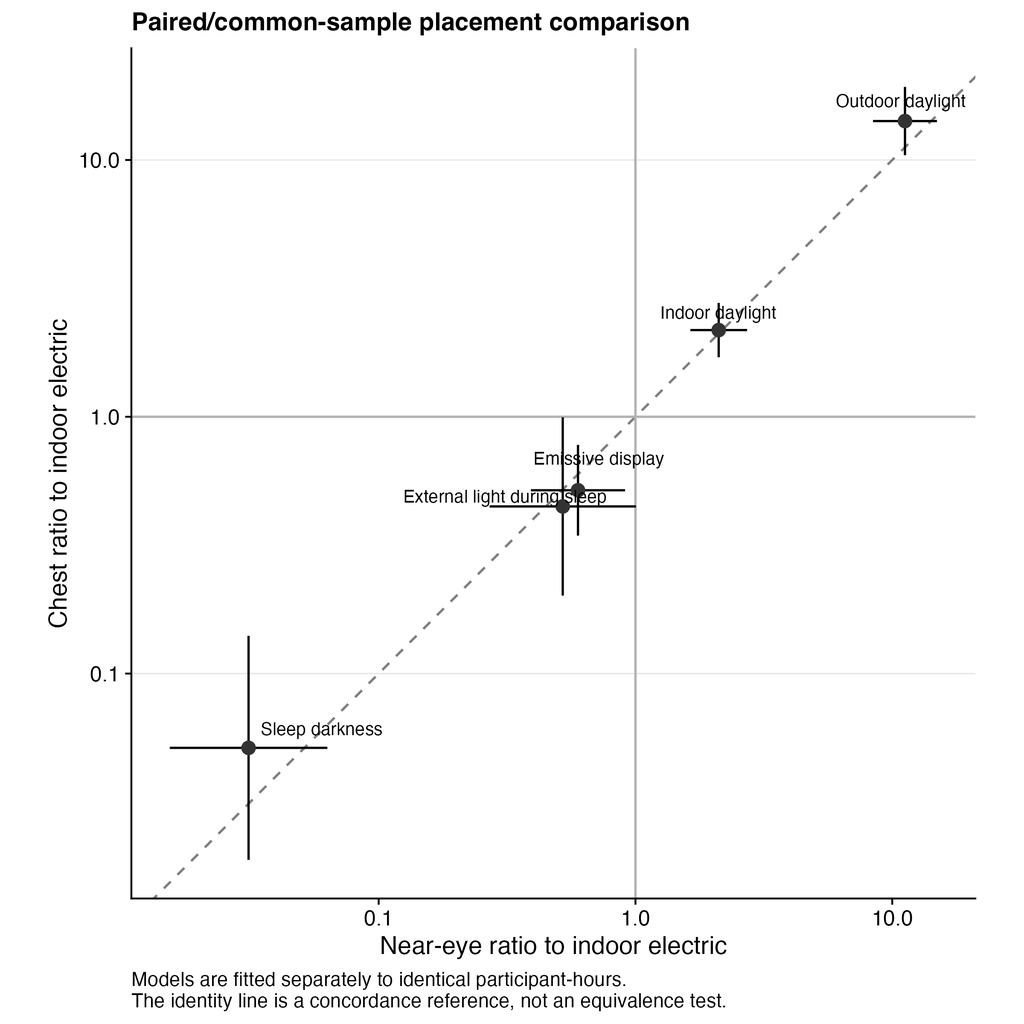

Figure 4: Paired/common-sample near-eye and chest category ratios. The identity line is not an equivalence boundary.

## 6 V0 reconstruction and corrections

V0 is reconstructed only as a bridge. It is not the approved analysis and it is not used to choose the Stage 2 result.

Table 13

V0 and approved-analysis denominators

Frozen V0 counts are preserved; the exact bridge reruns the V0 formula on currently recoverable five-category rows

| Placement | Implementation | Participant-hours | Categories | Test definition |
| --- | --- | --- | --- | --- |
| Near-eye | Frozen V0 | 16,774 | 5 | site-only versus category-plus-site-interaction likelihood-ratio test |
| Chest | Frozen V0 | 18,391 | 5 | site-only versus category-plus-site-interaction likelihood-ratio test |
| Near-eye | Exact V0 bridge on current common rows | 16,879 | 5 | site-only versus category-plus-site-interaction likelihood-ratio test |
| Chest | Exact V0 bridge on current common rows | 18,534 | 5 | site-only versus category-plus-site-interaction likelihood-ratio test |
| Near-eye | Approved H03 Stage 2 | 17,935 | 7 | separate six-restriction category robust Wald-F and site-heterogeneity robust Wald-F tests |
| Chest | Approved H03 Stage 2 | 19,512 | 7 | separate six-restriction category robust Wald-F and site-heterogeneity robust Wald-F tests |

The exact V0 bridge converged, had positive-definite Hessians, and was non-singular at both placements. Its likelihood-ratio test is <0.001 near eye and <0.001 at chest, but that test jointly adds four category main effects and all corresponding category-by-site interactions. It is not the six-restriction H03-F1 category omnibus.

Stage 2 corrects the consequential V0 issues explicitly:

1. V0 entered five categories; the approved analysis audits and estimates all seven registered categories.
2. Frozen V0 reported 16,774 near-eye and 18,391 chest rows. The exact current V0 bridge contains 16,879 and 18,534 rows, whereas the approved analysis contains 17,935 and 19,512 rows. Each number is labelled as participant- hours, not participants.
3. V0 combined category association and site heterogeneity in one likelihood- ratio test. Stage 2 reports separate F1 and F3 tests.
4. V0’s pooled `emmeans` contrasts used the Dunnett-X default but were labelled FDR-adjusted in the table. Stage 2 uses one explicit six-member BH family.
5. V0 removed confidence-limit columns. Stage 2 reports participant-cluster- robust 95% intervals for every estimable practical contrast.
6. The copied chest interpretation is not retained; chest estimates are calculated and interpreted from the chest fit.

## 7 Exploratory time-of-day context

**NoteExploratory model — separate from preregistered inference**

The GAM/GAMM context does not use indoor electric light as a reference curve. It contains one global cyclic time-of-day smooth plus sum-to-zero light-source smooth deviations around that global curve, sum-to-zero site deviations, participant factor smooths, participant-day random intercepts, and a boundary-aware AR(1) correction. Its R² and variance allocations are in-sample descriptive quantities on `log10(melEDI + 0.1 lx)`, not additions to the primary p-value families.

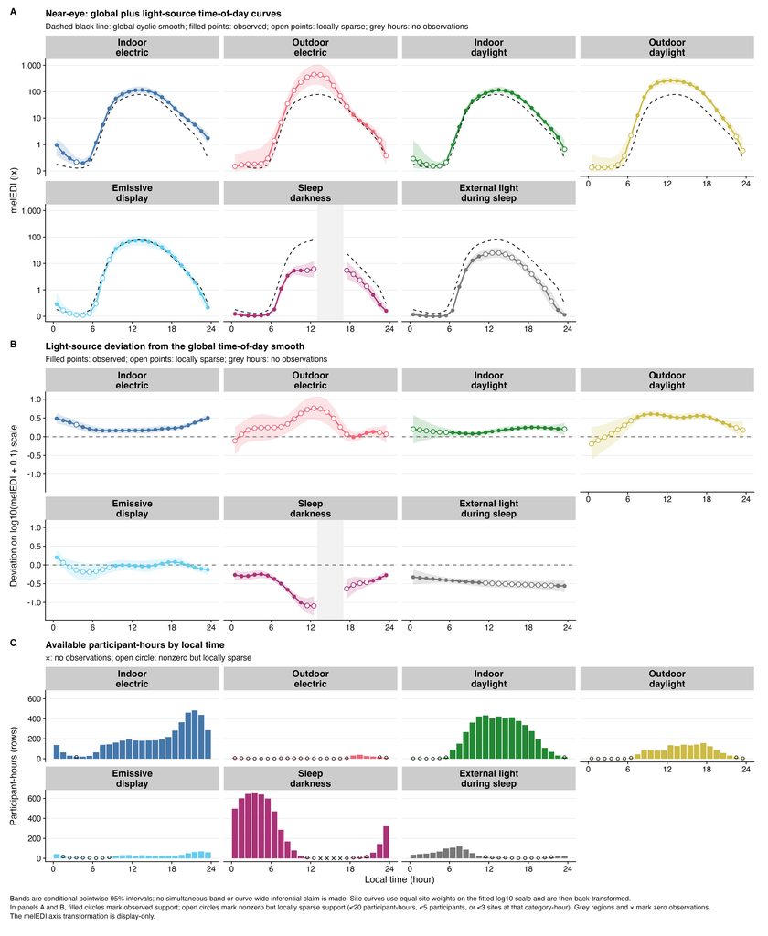

Figure 5: Exploratory near-eye global-plus-light-source time-of-day curves, category deviations, and available participant-hours. In panels A and B, filled circles mark observed category-hours that pass the local-support rule; open circles mark nonzero but locally sparse support: fewer than 20 participant-hours, 5 participants, or 3 sites. Light-grey regions in panels A and B and crosses in panel C mean zero observations, with no curve or ribbon drawn.

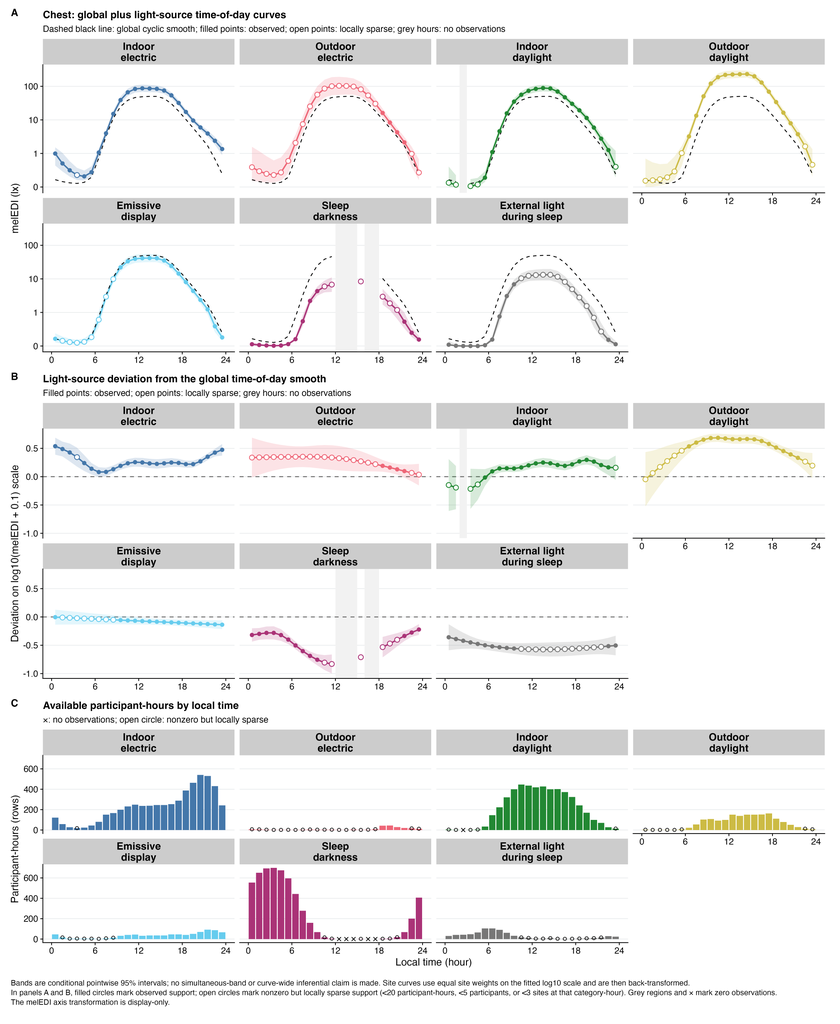

Figure 6: Exploratory chest global-plus-light-source time-of-day curves, category deviations, and available participant-hours. In panels A and B, filled circles mark observed category-hours that pass the local-support rule; open circles mark nonzero but locally sparse support: fewer than 20 participant-hours, 5 participants, or 3 sites. Light-grey regions in panels A and B and crosses in panel C mean zero observations, with no curve or ribbon drawn.

### 7.1 R² and variance decomposition

Table 14

Exploratory temporal model fit

R² values are descriptive in-sample transformed-response summaries

| Placement | Hours | Participants | Participant-days | AR rho | Adjusted R² | Deviance explained | Site-standardized participant-balanced R² |
| --- | --- | --- | --- | --- | --- | --- | --- |
| Near-eye | 17,935 | 140 | 801 | 0.417 | 0.823 | 0.835 | 0.831 |
| Chest | 19,512 | 151 | 880 | 0.410 | 0.780 | 0.792 | 0.789 |

Table 15

Point variance allocation

Exact conditional Shapley allocation of fitted linear-predictor variance under site-standardized, participant-balanced weights; no simulation interval was computed.

| Component | Shapley share | Unique partial share |
| --- | --- | --- |
| Near-eye |  |  |
| Global time of day | 67.4% | 43.4% |
| Light-source deviations | 16.5% | 4.6% |
| Site deviations | 4.9% | 4.6% |
| Participant curves | 10.0% | 8.3% |
| Participant-day shifts | 1.2% | 0.8% |
| Chest |  |  |
| Global time of day | 64.2% | 35.6% |
| Light-source deviations | 20.4% | 5.3% |
| Site deviations | 4.4% | 4.3% |
| Participant curves | 9.1% | 7.6% |
| Participant-day shifts | 1.9% | 1.3% |

The global daily curve receives 67.4% of the near-eye and 64.2% of the chest point allocation. Light-source deviations receive 16.5% and 20.4%, site deviations 4.9% and 4.4%, participant curves 10.0% and 9.1%, and participant- day shifts 1.2% and 1.9%. These components share covariance; the Shapley rule allocates that covariance exactly. They are not independent causal contributions.

### 7.2 Temporal diagnostics and limitations

Table 16

Exploratory temporal diagnostics

Lme-style singularity is not defined for penalized bam; the smoothing-parameter Hessian and penalty components are inspected instead

| Placement | Convergence | Optimizer iterations | Maximum \|gradient\| | Smoothing Hessian minimum eigenvalue | Smoothing Hessian PD | Residual lag-1 r | Residual excess kurtosis |
| --- | --- | --- | --- | --- | --- | --- | --- |
| Near-eye | full convergence | 17 | 4.89e-04 | 7.85e-05 | TRUE | 0.096 | 3.05 |
| Chest | full convergence | 21 | 1.36e-04 | -1.23e-04 | FALSE | 0.091 | 2.17 |

Both fits report full `mgcv` convergence. The near-eye smoothing Hessian is positive definite. The chest Hessian has one slightly non-positive direction (minimum eigenvalue -0.000123), so chest smoothing-parameter uncertainty is less secure. Standard `mgcv` full concurvity could not be computed near eye because its LAPACK SVD failed; the clearly labelled fitted-term fallback has a maximum multiple R² of 0.265. Chest full concurvity is available and is high for the global time and site components, indicating that their separate attribution is unstable even though the summed prediction is estimable.

The deterministic, zero-resample basis check gives global time k-indices of 0.978 near eye and 0.970 at chest. The global smooth uses 9.69 and 9.56 of ten available effective degrees of freedom, so basis capacity is close to its ceiling. No permutation p-value was computed. Standardized residual lag-1 correlation falls to 0.096 and 0.091 after AR adjustment, but residual tails remain heavier than Gaussian.

The inherited H02 specification uses a cyclic global curve but default thin- plate marginal bases for the category and site sum-to-zero deviations. The sum-to-zero constraints pass at less than 1.6e-15, but the non-cyclic deviations allow 24-hour versus 0-hour endpoint differences up to 0.408 on the log10 scale. The temporal figures use 0.5–23.5 hour centers and make no curve-wide inferential claim.

At the author’s request, a bounded same-row comparison replaced both `sz` marginal bases with cyclic bases. Both candidate fits used Gaussian `bam`, fREML, the same estimated-then-fixed AR(1) procedure, and no diagnostic simulation or resampling.

Table 17

Temporal-basis candidates

Only the light-source and site sz marginal bases differ

| Candidate | Exact Wilkinson formula supplied to bam |
| --- | --- |
| Inherited thin-plate sz | h03_temporal_response ~ s(time_hour, bs = "cc", k = 12) + s(time_hour, light_source, bs = "sz", k = 12) + s(time_hour, site, bs = "sz", k = 12) + s(time_hour, participant, bs = "fs", k = 10) + s(parti… |
| Fully cyclic sz | h03_temporal_response ~ s(time_hour, bs = "cc", k = 12) + s(time_hour, light_source, bs = "sz", k = 12, xt = list(bs = "cc")) + s(time_hour, site, bs = "sz", k = 12, xt = list(bs = "cc")) + s(time_hou… |

Table 18

Bounded temporal-basis comparison

Identical fitted rows; lower AIC and residual scale and higher adjusted R² favour fit, while midnight continuity is a structural criterion. The fREML score is shown but not used alone for selection because the smooth design spaces differ.

| Candidate | AIC | fREML score | Adjusted R² | Residual scale | Residual lag-1 r | Maximum category midnight gap | Maximum site midnight gap | Smoothing Hessian PD |
| --- | --- | --- | --- | --- | --- | --- | --- | --- |
| Near-eye |  |  |  |  |  |  |  |  |
| Inherited thin-plate sz | 29351.2 | 15386.0 | 0.8234 | 0.3378 | 0.096 | 4.08e-01 | 3.61e-01 | TRUE |
| Fully cyclic sz | 29384.4 | 15347.9 | 0.8229 | 0.3388 | 0.097 | 1.86e-16 | 2.02e-16 | TRUE |
| Chest |  |  |  |  |  |  |  |  |
| Inherited thin-plate sz | 36226.2 | 18690.1 | 0.7803 | 0.4215 | 0.091 | 3.15e-01 | 3.60e-01 | FALSE |
| Fully cyclic sz | 36256.0 | 18652.7 | 0.7797 | 0.4225 | 0.092 | 1.25e-16 | 1.53e-16 | TRUE |

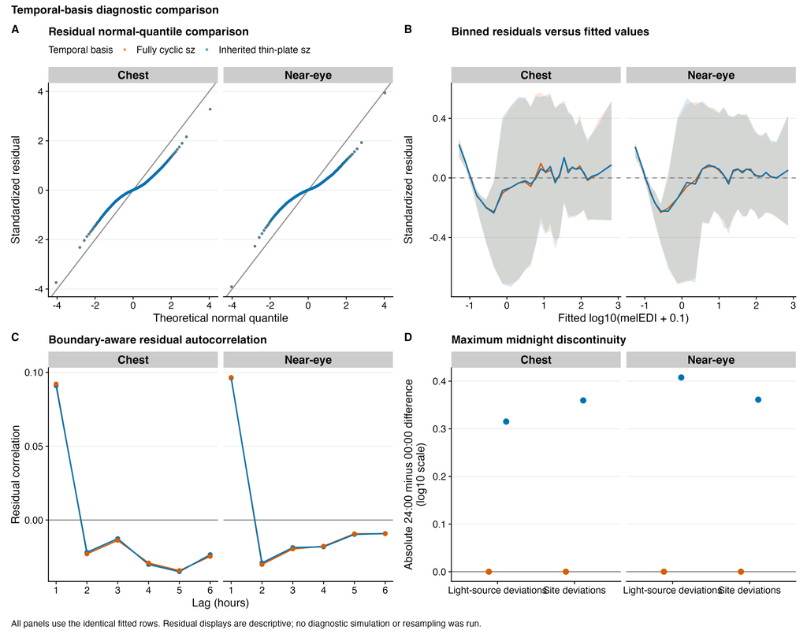

Figure 7: Diagnostic comparison of the inherited thin-plate sz and fully cyclic sz temporal models on identical fitted participant-hours. Panels show sampled normal-quantile residual points, binned residuals versus fitted values, boundary-aware residual autocorrelation, and the maximum 24:00-versus-00:00 discontinuity for light-source and site deviations. No diagnostic simulation or resampling was run.

## 8 Computation gate

Table 19

Deferred computation

No production bootstrap, simultaneous-band simulation, or variance-allocation uncertainty simulation was run

| Component | Status | Reason | Pilot / production state |
| --- | --- | --- | --- |
| site-stratified participant bootstrap | DEFERRED | 50-replicate feasibility pilot completed in Stage 1; production requires approval | production not run |
| simultaneous temporal bands | DEFERRED | requires a 100-draw pilot and separate production approval | pilot not yet run |
| temporal Shapley uncertainty simulation | DEFERRED | exact point allocation does not require simulation; interval simulation requires approval | production not run |

The Stage 1 site-bootstrap pilot remains the only bootstrap work. No production bootstrap was run. The deterministic GAM basis check uses zero resampling replicates, and the point Shapley allocation uses no simulation. Any production uncertainty computation still requires explicit approval.

## 9 Reproducibility and author gate

All scientific computation used R 4.6.1 and the existing project library. Input hashes were verified before each fit. Model objects, exact model frames, diagnostic tables, source CSVs, PNG/PDF/SVG figures, and run manifests are stored under the H03 artifact directories. This report reads those artifacts; it does not refit a model.

Stage 2 is now complete for author review. Stage 3 must not start until the author approves the inferential interpretation and decides whether the exploratory temporal model’s inherited non-cyclic deviation bases and chest smoothing-Hessian/concurvity limitations are acceptable, should be amended, or should keep the temporal result out of the standalone report.